# BSTS

Time Series

Bayesian Structural Time Series method for Time series data

Yeongeun Jeon  
07-14-2021

- Data 출처 : [Data Mining for Business Analytics](https://www.dataminingbook.com/book/r-edition)에서 사용한 미국 철도 회사 “Amtrak”에서 수집한 1991년 1월~2004년 3월까지 매달 환승 고객 수

# **Introduction**

Bayesian Structural Time Series (BSTS)는 Dynamic Linear Model (DLM)을 이용하여 시계열 자료를 모형화하고 Markov chain Monte Carlo (MCMC)를 사용하여 적합시킨다. Structural Time Series은 Linear Gaussian State Space Model로써 DLM과 동일한 개념으로 쓰이기 때문이다.

# **DLM**

DLM은 상태공간모형 (state space model)에서 선형성 (linear)과 정규분포 (Gaussian distribution)를 가정하는 모형이다.

- 관측된 시계열자료를 직접 관찰할 수 없는/측정되지 않은 상태로 표현하는 모형 (상태 예: 추세, 계절성 등)
- 비정상성 시계열을 모형화하는 데 유용
- 데이터 변형 없이 원 시계열(Original Time Series)에 모형 적용
- 시간에 따라 변하는 회귀계수를 가지는 선형회귀모형의 일반화 형태

## **DLM 모형식**

DLM은 두 개의 방정식으로 구성되어 있다.

$$\begin{aligned}
Y_{t}&=F_{t}\theta_{t}+v_{t},~~~~~~~v_{t}\sim N_{m}(0,V_{t}), \\
\theta_{t}&=G_{t}\theta_{t-1}+\omega_{t},~~~\omega_{t}\sim N_{p}(0,W_{t}).
\end{aligned}$$

- 첫번째는 관측방정식, 두번째는 상태방정식이다.
  - $Y_{t}$ : 시점 $t$에서 관측값
  - $\theta_{t}$ : 시점 $t$에서 시스템의 관측할 수 없는 상태 (시계열에서 추세, 계절성 등 성분이 상태가 될 수 있음)
  - $F_{t}$, $G_{t}$ : 알고 있는 행렬
  - $v_{t}$, $\omega_{t}$ : 오차
  - $V_{t}$, $W_{t}$ : 알고 있는 공분산 행렬
- 수식을 보면 시점 $t$에 의존하여 시간에 따라 회귀 계수가 변화할 수 있다.

# **예제**

- Ridership on Amtrak Trains(미국 철도 회사 “Amtrak”에서 수집한 1991년 1월~2004년 3월까지 매달 환승 고객 수) 예제를 이용하여 BSTS이 실제 데이터에 어떻게 적용되는지 설명한다.

```
# Data 불러오기기

  Amtrak.data <- data.table::fread(paste(getwd(),"Amtrak.csv", sep="/"))
```

```
ridership.ts <- ts(Amtrak.data$Ridership, start=c(1991,1), end=c(2004,3), freq=12)
train.ts     <- window(ridership.ts,start=c(1991,1), end=c(2001,3))   # Training Data
test.ts      <- window(ridership.ts,start=c(2001,4))                  # Test Data
n.test       <- length(test.ts)
```

## **정규성 확인**

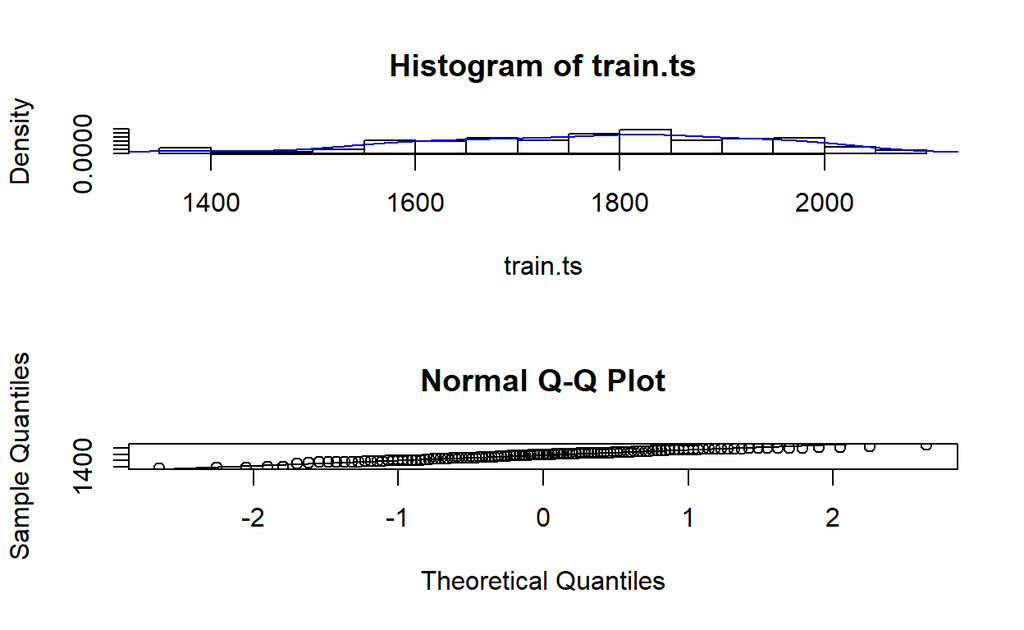

```
par(mfrow=c(2,1))
hist(train.ts, prob=TRUE, 12)
lines(density(train.ts), col="blue")
qqnorm(train.ts)
qqline(train.ts)
```

- 두 그래프를 보면 Ridership은 정규분포를 따른다는 것을 알 수 있다.

## **분해 (Decomposition)**

- 시계열은 다양한 패턴으로 나타날 수 있다. (추세, 계절성 등)
- 시계열을 몇 가지 성분으로 나누는 작업은 시계열을 이해하는데 종종 도움이 된다.
- DLM은 가법 분해 (관측된 시계열을 다른 성분들의 합으로 표현)를 사용한다.
- R 함수 `decompose()`를 이용하여 데이터를 추세와 계절성, 불규칙 성분으로 나눌 수 있다.

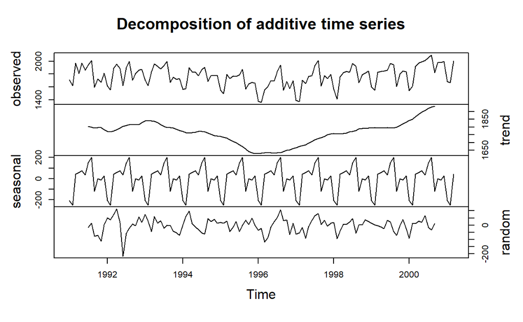

```
plot(decompose(train.ts), yax.flip=TRUE)
```

## **모형화**

DLM의 대표적인 모형으로는 Local Level, Local Linear Trend, Regression with Seasonal Dummy Variables가 있다.

### **Local Level Model**

추세에 대한 모델이며 추세의 평균인 Level (Random Walk) + 오차로 이루어져있다. 모형식은 아래와 같으며, R package `"bsts"`에서 `AddLocalLevel()`을 사용하면 된다.

$$\begin{aligned}
Y_{t} &= \mu_{t} + v_{t},~~~~~~~v_{t}\sim N(0,V)\\
\mu_{t} &= \mu_{t-1} + \omega_{t}, ~~~\omega_{t}\sim N(0,\sigma^2_{\mu }).
\end{aligned}$$

```
ss <- list()
ss <- bsts::AddLocalLevel(ss, y)   # y : The time series to be modeled
```

### **Local Linear Trend Model**

추세에 대한 모델이며 추세의 평균인 Level (Random Walk) + 추세의 기울기 (=추세의 증가률) + 오차로 이루어져있다. 모형식은 아래와 같으며, R package `"bsts"`에서 `AddLocalLinearTrend()`을 사용하면 된다.

$$\begin{aligned}
Y_{t} &= \mu_{t} + v_{t},~~~~~~~v_{t}\sim N(0,V)\\
\mu_{t} &= \mu_{t-1} + \beta_{t} + \omega_{t,1}, ~~~\omega_{t,1}\sim N(0,\sigma^2_{\mu }),\\
\beta_{t} &= \beta_{t-1} + \omega_{t,2}, ~~~\omega_{t,2}\sim N(0,\sigma^2_{\beta}).
\end{aligned}$$

```
ss <- list()
ss <- bsts::AddLocalLinearTrend(ss, y)   # y : The time series to be modeled
```

### **Regression with Seasonal Dummy Variables**

계절성(Seasonality)에 대한 모델이며, 모형식은 아래와 같으며, R package `"bsts"`에서 `AddSeasonal()`을 사용하면 된다.

$$\begin{aligned}
Y_{t} &= \tau_{t} + v_{t},~~~~~~~v_{t}\sim N(0,V)\\
\tau{t} &= -\sum_{s=1}^{S-1} \tau_{t-s} + \eta_{t}, ~~~\eta_{t}\sim N(0,\sigma^2_{\eta}).
\end{aligned}$$

```
ss <- list()
ss <- bsts::AddSeasonal(ss, y,           # y : The time series to be modeled
                        nseasons,        # season.duration의 반복 수
                        season.duration) # 각 시즌에서 관측수수

# cycle (s) = season.duration * nseasons
```

예제 데이터에 BSTS를 적용하기 위해서 시계열 데이터에 Local Linear Trend + Seasonal을 모형화하였다.

```
pacman::p_load("bsts")

# Local Linear Trend
ss <- list()
ss <- bsts::AddLocalLinearTrend(ss, train.ts)
# Seasonal
ss <- bsts::AddSeasonal(ss, train.ts, nseasons = 12, season.duration = 1)
```

## **적합**

```
Train.BSTS <- bsts(train.ts, state.specification = ss, niter = 1000, seed=100)  # niter : MCMC 반복복
```

[output not shown]

```
summary(Train.BSTS)
```

```
$residual.sd
[1] 38.96105

$prediction.sd
[1] 86.43389

$rsquare
[1] 0.9407548

$relative.gof
[1] 0.7354909
```

## **예측**

```
burn <- SuggestBurn(0.1, Train.BSTS)   # MCMC에서 버릴 갯수릴 갯수
Pred.BSTS <- predict(Train.BSTS, horizon = n.test, burn = burn,  quantiles = c(0.025, 0.975))  # horizon : the number of prediction

Pred.BSTS$mean
```

```
 [1] 2008.007 2034.247 2005.145 2114.927 2159.952 1849.643 1985.271
 [8] 1980.410 2025.083 1771.644 1738.847 2042.618 2047.263 2078.716
[15] 2049.774 2156.080 2205.664 1890.307 2028.975 2029.909 2066.173
[22] 1817.965 1788.446 2091.587 2098.778 2123.918 2100.609 2209.087
[29] 2258.041 1946.782 2080.985 2076.564 2118.590 1871.648 1843.989
[36] 2146.205
```

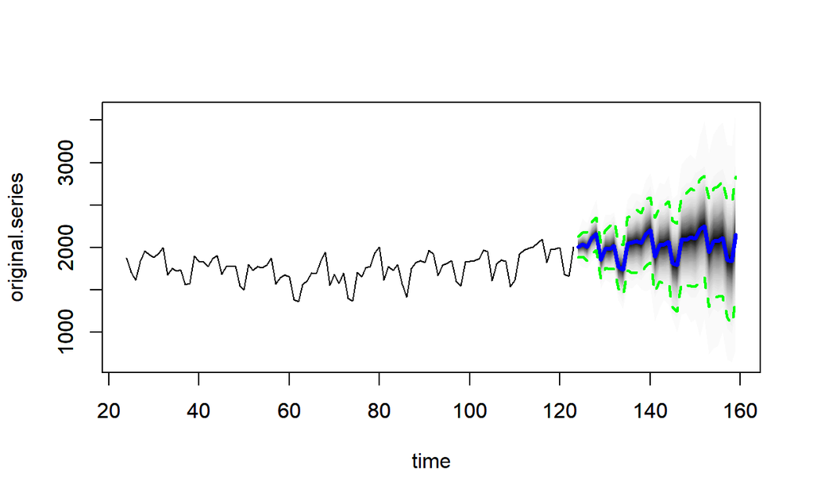

```
plot(Pred.BSTS, plot.original = 100)
```